# Feather River Mini Snorkel Data QC

Maddee Rubenson

August 21, 2024

# Feather River Mini Snorkel Data - 2001 & 2002

## Description of Monitoring Data

This markdown explores the data that was provided for mini snorkel data for Feather River in the database: `minisnorkdb3.mdb`. Previously, a database was provided that only contained 2001 data (`MiniSnorkelDTB.mdb`). Upon exploration and comparison between this new database and the old database, it was decided that we will move forward using this database for publishing on EDI. For details on the `MiniSnorkelDTB` database visit: `qc_mini_snorkel_data.Rmd` and for details on the database comparison, visit: `database_qc.Rmd`.

**Timeframe:** March 2001 - August 2002

**Completeness of Record throughout timeframe:** fairly complete

**Sampling Location:** Feather River

**Data Contact:** Ryon Kurth

## Source Database pull

- Database name: `minisnorkdb3.mdb`

Read in data sourced from query script, glimpse raw data and domain description sheet:

```r
# read in data to clean
microhabitat_2002 |> glimpse()
```

```
## Rows: 9,645
## Columns: 26
## $ MicroHabDataTblID <int> 18, 19, 20, 21, 22, 23, 24, 25, 26, 27, 28, 29, 30, …
## $ PDatID            <int> 11, 11, 11, 11, 11, 11, 11, 11, 11, 11, 11, 11, 11, …
## $ TCode             <dbl> 0.1, 0.2, 0.3, 0.4, 3.1, 3.2, 3.3, 3.4, 6.1, 6.2, 6.…
## $ Depth             <dbl> 17, 19, 11, 12, 11, 10, 8, 9, 10, 19, 19, 37, 16, 14…
## $ Velocity          <dbl> 0.22, 0.35, 1.95, 2.14, 1.19, 1.54, 1.26, 1.97, 0.75…
## $ Sub1              <int> 0, 0, 0, 0, 0, 0, 0, 0, 40, 0, 0, 0, 0, 0, 0, 0, 15,…
## $ Sub2              <int> 40, 50, 25, 0, 70, 30, 0, 0, 0, 60, 30, 65, 80, 0, 0…
## $ Sub3              <int> 20, 40, 75, 80, 30, 50, 60, 70, 40, 30, 50, 25, 20, …
## $ Sub4              <int> 30, 10, 0, 20, 0, 20, 40, 30, 20, 10, 20, 10, 0, 15,…
## $ Sub5              <int> 10, 0, 0, 0, 0, 0, 0, 0, 0, 0, 0, 0, 0, 0, 0, 0, 0, …
## $ Sub6              <int> 0, 0, 0, 0, 0, 0, 0, 0, 0, 0, 0, 0, 0, 0, 0, 0, 0, 0…
## $ IcovA             <int> 75, 100, 100, 100, 10, 100, 100, 100, 50, 100, 100, …
## $ IcovB             <int> 15, 0, 0, 0, 20, 0, 0, 0, 10, 0, 0, 0, 10, 0, 0, 0, …
## $ IcovC             <int> 0, 0, 0, 0, 40, 0, 0, 0, 0, 0, 0, 0, 0, 0, 0, 0, 0, …
## $ IcovE             <int> 10, 0, 0, 0, 30, 0, 0, 0, 40, 0, 0, 0, 0, 0, 0, 0, 0…
## $ IcovF             <int> 0, 0, 0, 0, 0, 0, 0, 0, 0, 0, 0, 0, 0, 0, 0, 0, 20, …
## $ Ocov0             <int> 100, 100, 100, 100, 100, 100, 100, 100, 75, 100, 100…
## $ Ocov1             <int> 0, 0, 0, 0, 0, 0, 0, 0, 25, 0, 0, 0, 50, 0, 0, 0, 0,…
## $ Ocov2             <int> 0, 0, 0, 0, 0, 0, 0, 0, 0, 0, 0, 0, 0, 0, 0, 0, 0, 0…
## $ SurTurb           <int> 20, 30, 30, 30, 10, 10, 10, 10, 0, 10, 20, 30, 0, 0,…
## $ CGU               <chr> "g", "g", "g", "g", "gm", "g", "g", "g", "gm", "gm",…
## $ SubSum            <int> 100, 100, 100, 100, 100, 100, 100, 100, 100, 100, 10…
## $ ICovSum           <int> 100, 100, 100, 100, 100, 100, 100, 100, 100, 100, 10…
## $ OCovSum           <int> 100, 100, 100, 100, 100, 100, 100, 100, 100, 100, 10…
## $ VelClicks         <int> NA, NA, NA, NA, NA, NA, NA, NA, NA, NA, NA, NA, NA, …
## $ AdjVel            <dbl> NA, NA, NA, NA, NA, NA, NA, NA, NA, NA, NA, NA, NA, …
```

## Data transformations

### first table reviewed is the All Fish Observation Table

All of the substrate and cover lookups are not true look ups. Substrate and cover column indicate a percentage of cover or substrate of each type. I updated the column names to reflect this and utilized the lookup tables to understand which substrate or cover type each column was referring to.

Columns removed:

- SpecAge removed - just a combination of species and age
- i_cov_sum - removed because sum of other columns
- o_cov_sum - removed because sum of other columns
- sub_sum - removed because sum of other columns
- start_time - just a date that seemed wrong
- end_time - also just a date that seemed wrong
- crew - specific crew names do not need to be present on public EDI dataset

```r
# Combine the data here
# 2001/2002 data
all_fish_data <- microhabitat_2002 |>
  left_join(fish_data_2002, by = c("TCode" = "TCode", "PDatID" = "PDatID")) |>
  left_join(species_code_lookup_2002, by = c("Species" = "SpeciesCodeID")) |> # all codes are in the lookup
  select(-c(SpeciesCode, Species)) |>
  rename(species = Species.y,
         percent_fine_substrate = Sub1,
         percent_sand_substrate = Sub2,
         percent_small_gravel_substrate = Sub3,
         percent_large_gravel_substrate = Sub4,
         percent_cobble_substrate = Sub5,
         percent_boulder_substrate = Sub6,
         percent_no_cover_inchannel = IcovA,
         percent_small_woody_cover_inchannel = IcovB,
         percent_large_woody_cover_inchannel = IcovC,
         percent_submerged_aquatic_veg_inchannel = IcovE,
         percent_undercut_bank = IcovF,
         percent_no_cover_overhead = Ocov0,
         percent_cover_half_meter_overhead = Ocov1,
         percent_cover_more_than_half_meter_overhead = Ocov2)|>
  # Clean in separate file
  left_join(location_table_2002, by = c("PDatID" = "PhysDataTblID")) |>
  left_join(weather_code_lookup_2002, by = c("Weather" = "WeatherCodeLookUpID")) |> # all codes are in the lookup
  select(-WeatherCode, -Weather) |>
  rename(weather = Weather.y) |>
  # note that there are 0 channel types which do not map to the lookup
  left_join(channel_lookup_2002, by = c("ChannelType" = "ChannelTypeCode")) |>
  select(-ChannelType, -ChannelTypeCodeID) |>
  rename(channel_type = ChannelType.y) |>
  janitor::clean_names() |>
  # fixes issues with the codes so the CGU lookup will work
  mutate(cgu = tolower(cgu),
         cgu = case_when(cgu == "rm`" ~ "rm",
                         cgu == "gm." ~ "gm",
                         cgu == "" ~ NA,
                         T ~ cgu)) |>
  left_join(cgu_code_lookup_2002 |> mutate(CGUCode = tolower(CGUCode)), by = c("cgu" = "CGUCode")) |>
  select(-cgu, -CGUCodeID, -sub_sum, -i_cov_sum, -o_cov_sum, -start_time, -end_time, -crew) |>
  rename(channel_geomorphic_unit = CGU) |>
  filter(!is.na(date)) |>
  write_csv('2002_fish_obs_tmp.csv') # annoying workaround to remove labeled date column

all_fish_data <- read_csv('2002_fish_obs_tmp.csv')  |> glimpse()
```

```
## Rows: 9,827
## Columns: 52
## $ micro_hab_data_tbl_id                       <dbl> 18, 18, 18, 19, 20, 21, 22…
## $ p_dat_id                                    <dbl> 11, 11, 11, 11, 11, 11, 11…
## $ t_code                                      <dbl> 0.1, 0.1, 0.1, 0.2, 0.3, 0…
## $ depth                                       <dbl> 17, 17, 17, 19, 11, 12, 11…
## $ velocity                                    <dbl> 0.22, 0.22, 0.22, 0.35, 1.…
## $ percent_fine_substrate                      <dbl> 0, 0, 0, 0, 0, 0, 0, 0, 0,…
## $ percent_sand_substrate                      <dbl> 40, 40, 40, 50, 25, 0, 70,…
## $ percent_small_gravel_substrate              <dbl> 20, 20, 20, 40, 75, 80, 30…
## $ percent_large_gravel_substrate              <dbl> 30, 30, 30, 10, 0, 20, 0, …
## $ percent_cobble_substrate                    <dbl> 10, 10, 10, 0, 0, 0, 0, 0,…
## $ percent_boulder_substrate                   <dbl> 0, 0, 0, 0, 0, 0, 0, 0, 0,…
## $ percent_no_cover_inchannel                  <dbl> 75, 75, 75, 100, 100, 100,…
## $ percent_small_woody_cover_inchannel         <dbl> 15, 15, 15, 0, 0, 0, 20, 0…
```

[output cut: 39 more lines]

**NA and Unknown Date Values**

There are 0 NA values

## Explore Numeric Variables:

```r
# Filter clean data to show only numeric variables
all_fish_data %>% select_if(is.numeric) %>% colnames()
```

```
##  [1] "micro_hab_data_tbl_id"
##  [2] "p_dat_id"
##  [3] "t_code"
##  [4] "depth"
##  [5] "velocity"
##  [6] "percent_fine_substrate"
##  [7] "percent_sand_substrate"
##  [8] "percent_small_gravel_substrate"
##  [9] "percent_large_gravel_substrate"
## [10] "percent_cobble_substrate"
## [11] "percent_boulder_substrate"
## [12] "percent_no_cover_inchannel"
## [13] "percent_small_woody_cover_inchannel"
## [14] "percent_large_woody_cover_inchannel"
## [15] "percent_submerged_aquatic_veg_inchannel"
```

[output cut: 30 more lines]

### Variable: `count`

**Plotting Count over Period of Record**

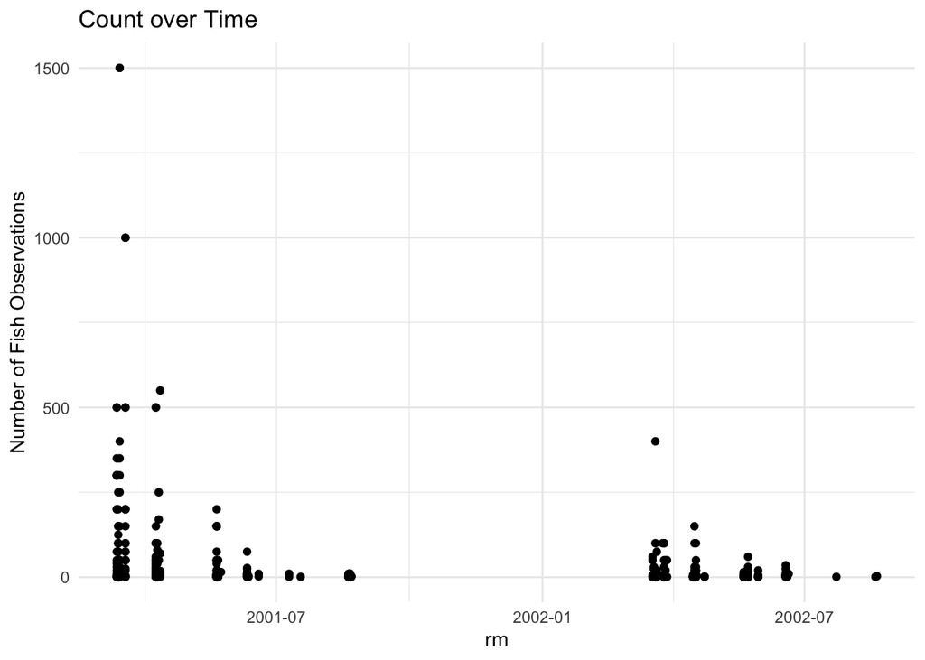

```r
# Make whatever plot is appropriate
# maybe 2+ plots are appropriate
all_fish_data %>%
  ggplot(aes(x = rm, y = count, group = 1))+
  # geom_line()+
  geom_point(aes(x=date, y = count))+
  theme_minimal()+
  labs(title = "Count over Time",
       y = "Number of Fish Observations")
```

**Numeric Summary of Count over Period of Record**

```r
# Table with summary statistics
summary(all_fish_data$count)
```

```
##    Min. 1st Qu.  Median    Mean 3rd Qu.    Max.    NA's
##    1.00    1.00    3.00   38.74   20.00 1500.00    9207
```

**NA and Unknown Values**

There are 9207 NA values

### Variable: `date`

**Plotting Date over Period of Record**

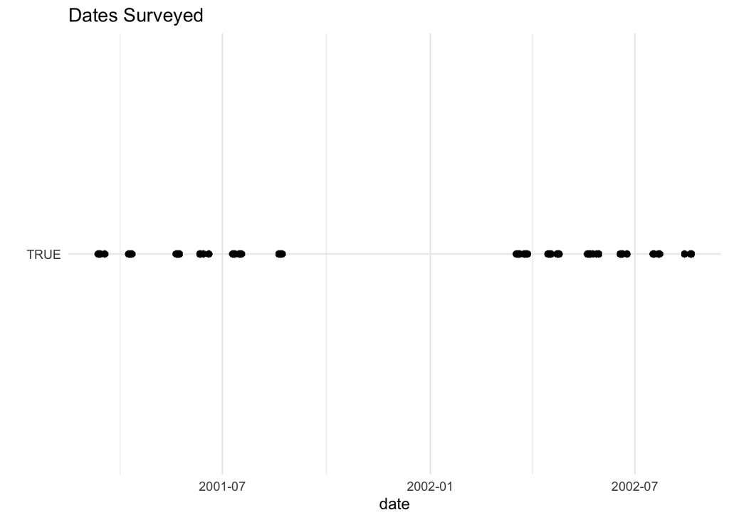

```r
# Make whatever plot is appropriate
# maybe 2+ plots are appropriate
all_fish_data %>%
  ggplot(aes(x = date, y = TRUE, group = 1))+
  # geom_line()+
  geom_point(aes(x=date, y = TRUE))+
  theme_minimal()+
  labs(title = "Dates Surveyed",
       y = "")
```

**Numeric Summary of Count over Period of Record**

```r
# Table with summary statistics
summary(all_fish_data$date)
```

```
##         Min.      1st Qu.       Median         Mean      3rd Qu.         Max.
## "2001-03-13" "2001-06-11" "2001-08-22" "2001-11-26" "2002-05-28" "2002-08-20"
```

**NA and Unknown Values**

There are 0 NA values

### Variable: `river_mile``

**Plotting river_mile over Period of Record**

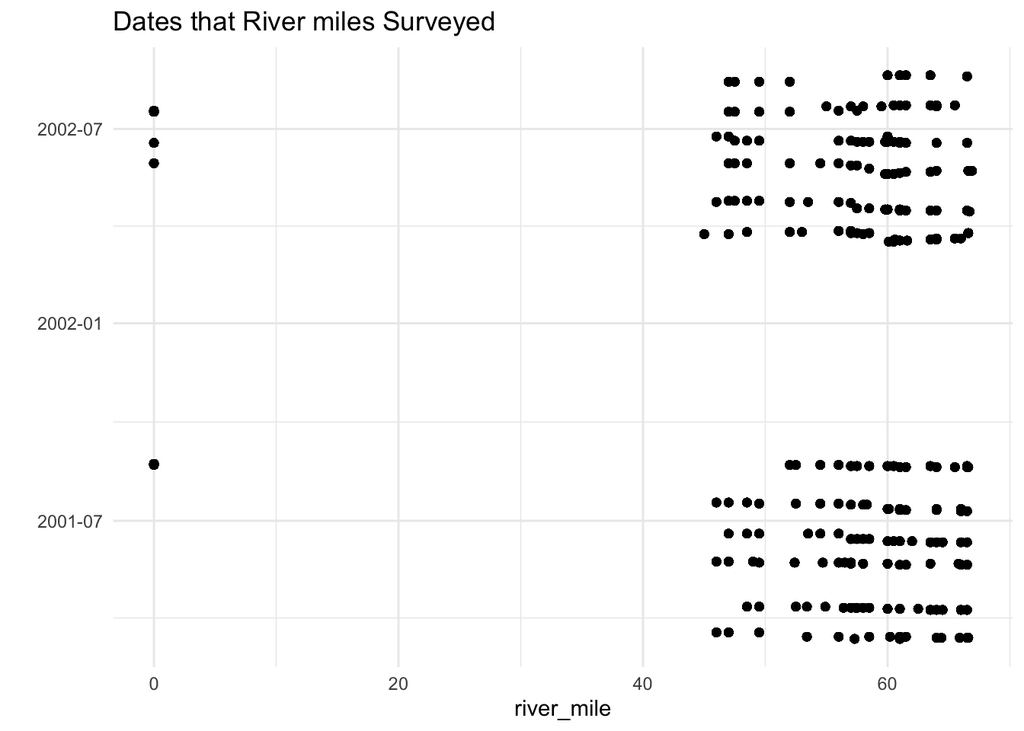

```r
# Make whatever plot is appropriate
# maybe 2+ plots are appropriate
all_fish_data %>%
  ggplot(aes(x = river_mile, y = date, group = 1))+
  # geom_line()+
  geom_point(aes(x=river_mile, y = date))+
  theme_minimal()+
  labs(title = "Dates that River miles Surveyed",
       y = "")
```

**Numeric Summary of river_mile over Period of Record**

```r
# Table with summary statistics
summary(all_fish_data$river_mile)
```

```
##    Min. 1st Qu.  Median    Mean 3rd Qu.    Max.
##    0.00   54.50   59.50   55.87   62.00   66.90
```

**NA and Unknown Values**

There are 0 NA values

### Variable: `fl_mm`

**Plotting fl_mm over Period of Record**

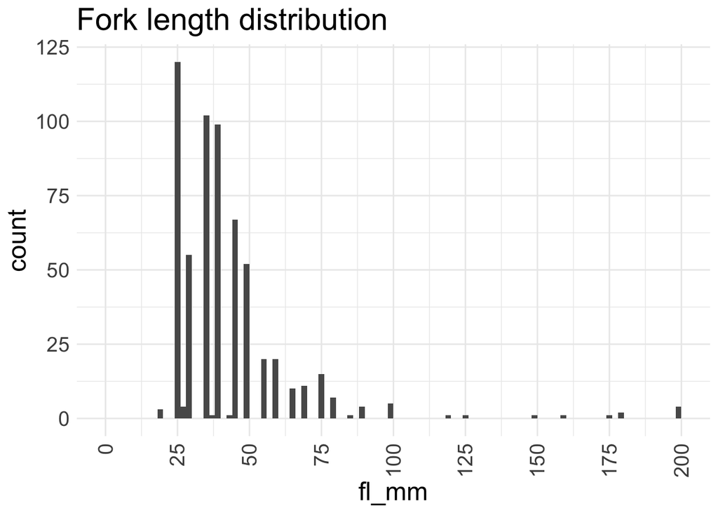

```r
# Make whatever plot is appropriate
# maybe 2+ plots are appropriate
all_fish_data |>
  # filter(fork_length < 250) %>% # filter out 13 points so we can more clearly see distribution
  ggplot(aes(x = fl_mm)) +
  geom_histogram(breaks=seq(0, 200, by=2)) +
  scale_x_continuous(breaks=seq(0, 200, by=25)) +
  theme_minimal() +
  labs(title = "Fork length distribution") +
  theme(text = element_text(size = 18),
        axis.text.x = element_text(angle = 90, vjust = 0.5, hjust=1))
```

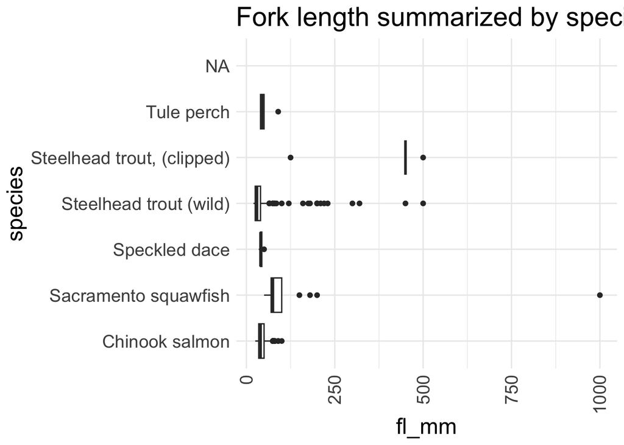

```r
all_fish_data %>%
  mutate(year = as.factor(year(date))) %>%
  ggplot(aes(x = fl_mm, y = species)) +
  geom_boxplot() +
  theme_minimal() +
  labs(title = "Fork length summarized by species") +
  theme(text = element_text(size = 18),
        axis.text.x = element_text(angle = 90, vjust = 0.5, hjust=1))
```

**Numeric Summary of fl_mm over Period of Record**

```r
# Table with summary statistics
summary(all_fish_data$fl_mm)
```

```
##    Min. 1st Qu.  Median    Mean 3rd Qu.    Max.    NA's
##   20.00   30.00   40.00   50.59   50.00 1000.00    9207
```

**NA and Unknown Values**

There are 9207 NA values

### Variable: `dist_to_bottom`

**Plotting dist_to_bottom distribution**

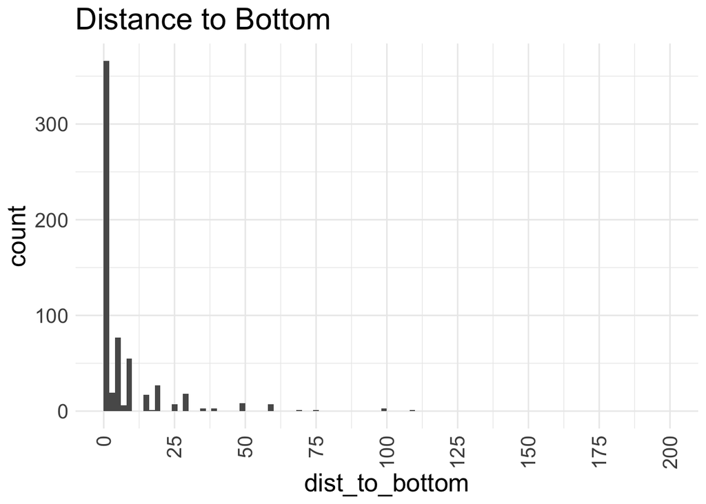

```r
# Make whatever plot is appropriate
# maybe 2+ plots are appropriate
all_fish_data |>
  # filter(fork_length < 250) %>% # filter out 13 points so we can more clearly see distribution
  ggplot(aes(x = dist_to_bottom)) +
  geom_histogram(breaks=seq(0, 200, by=2)) +
  scale_x_continuous(breaks=seq(0, 200, by=25)) +
  theme_minimal() +
  labs(title = "Distance to Bottom") +
  theme(text = element_text(size = 18),
        axis.text.x = element_text(angle = 90, vjust = 0.5, hjust=1))
```

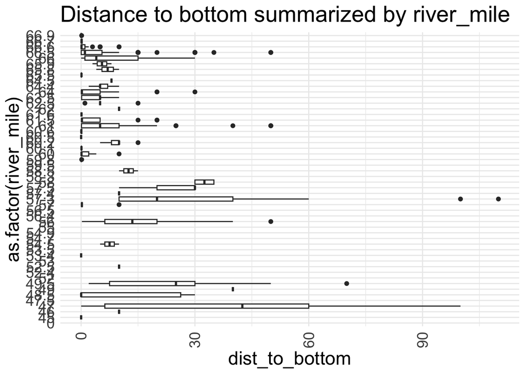

```r
all_fish_data %>%
  mutate(year = as.factor(year(date))) %>%
  ggplot(aes(x = dist_to_bottom, y = as.factor(river_mile))) +
  geom_boxplot() +
  theme_minimal() +
  labs(title = "Distance to bottom summarized by river_mile") +
  theme(text = element_text(size = 18),
        axis.text.x = element_text(angle = 90, vjust = 0.5, hjust=1))
```

```r
# Table with summary statistics
summary(all_fish_data$river_mile)
```

```
##    Min. 1st Qu.  Median    Mean 3rd Qu.    Max.
##    0.00   54.50   59.50   55.87   62.00   66.90
```

### Variable: `focal_velocity` & `velocity`

**Plotting velocities over Period of Record**

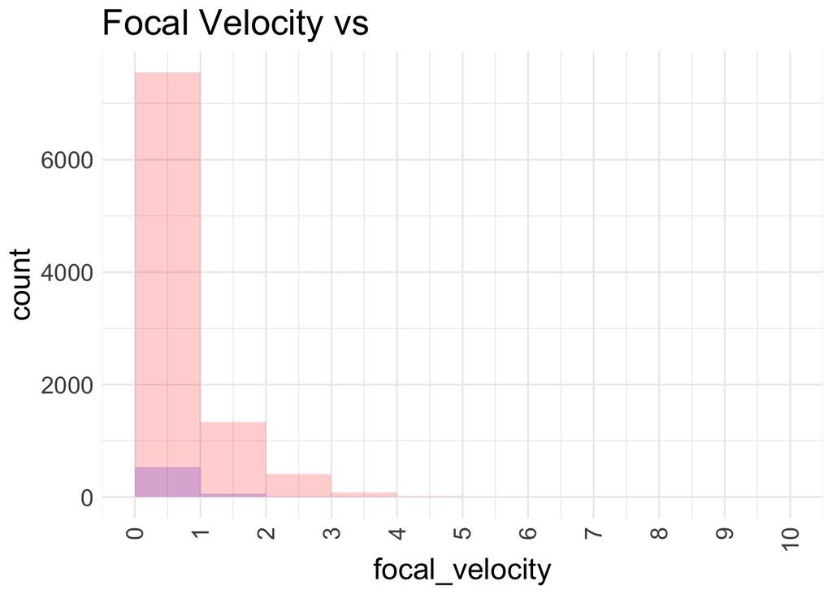

```r
all_fish_data |>
  # filter(fork_length < 250) %>% # filter out 13 points so we can more clearly see distribution
  ggplot(aes(x = focal_velocity)) +
  geom_histogram(breaks=seq(0, 10, by=1), group = "Focal velocity", fill = "blue", alpha = .2 ) +
  geom_histogram(aes(x = velocity), breaks=seq(0, 10, by=1), group = "Focal velocity", fill = "red", alpha = .2 ) +
  scale_x_continuous(breaks=seq(0, 10, by=1)) +
  theme_minimal() +
  labs(title = "Focal Velocity vs ") +
  theme(text = element_text(size = 18),
        axis.text.x = element_text(angle = 90, vjust = 0.5, hjust=1))
```

Looks like velocity and focal velocity have similar distributions

**Numeric Summary of focal_velocity over Period of Record**

```r
# Table with summary statistics
summary(all_fish_data$focal_velocity)
```

```
##    Min. 1st Qu.  Median    Mean 3rd Qu.    Max.    NA's
##   0.000   0.000   0.000   0.355   0.580   3.440    9219
```

```r
summary(all_fish_data$velocity)
```

```
##    Min. 1st Qu.  Median    Mean 3rd Qu.    Max.    NA's
##  0.0000  0.0000  0.0000  0.4840  0.7925  5.7300     435
```

**NA and Unknown Values**

There are 9219 NA values There are 435 NA values

### Variable: `t_code`

**Plotting t_code over Period of Record**

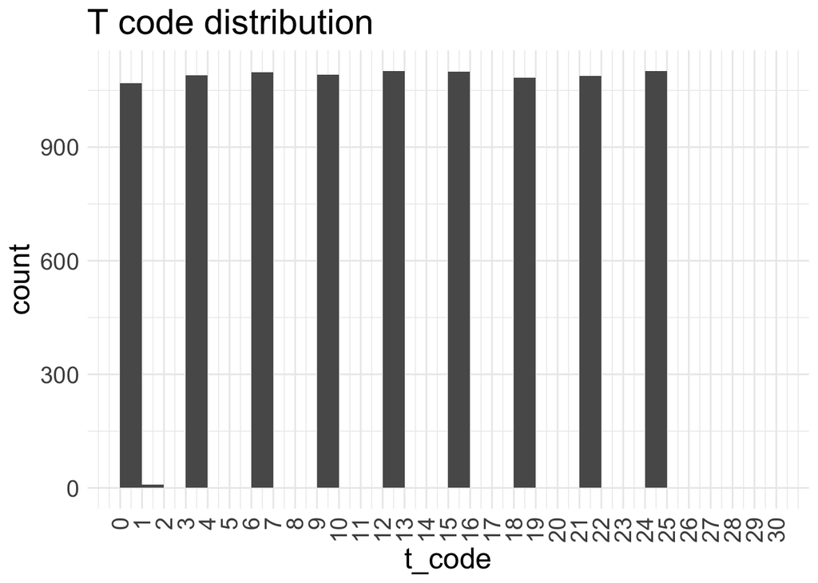

```r
all_fish_data |>
  # filter(fork_length < 250) %>% # filter out 13 points so we can more clearly see distribution
  ggplot(aes(x = t_code)) +
  geom_histogram(breaks=seq(0, 30, by=1)) +
  scale_x_continuous(breaks=seq(0, 30, by=1)) +
  theme_minimal() +
  labs(title = "T code distribution") +
  theme(text = element_text(size = 18),
        axis.text.x = element_text(angle = 90, vjust = 0.5, hjust=1))
```

**Numeric Summary of t_code over Period of Record**

```r
# Table with summary statistics
summary(all_fish_data$t_code)
```

```
##    Min. 1st Qu.  Median    Mean 3rd Qu.    Max.
##    0.10    6.20   12.20   12.27   18.35   24.40
```

**NA and Unknown Values**

There are 0 NA values

### Variable: `depth`

**Plotting depth over Period of Record**

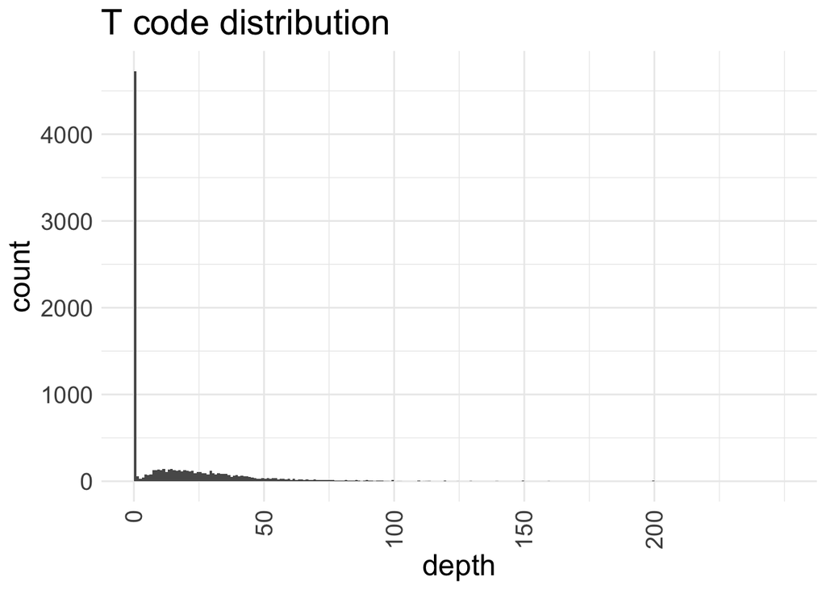

```r
all_fish_data |>
  # filter(fork_length < 250) %>% # filter out 13 points so we can more clearly see distribution
  ggplot(aes(x = depth)) +
  geom_histogram(breaks=seq(0, 250, by=1)) +
  scale_x_continuous(breaks=seq(0, 200, by=50)) +
  theme_minimal() +
  labs(title = "T code distribution") +
  theme(text = element_text(size = 18),
        axis.text.x = element_text(angle = 90, vjust = 0.5, hjust=1))
```

**Numeric Summary of depth over Period of Record**

```r
# Table with summary statistics
summary(all_fish_data$depth)
```

```
##    Min. 1st Qu.  Median    Mean 3rd Qu.    Max.    NA's
##    0.00    0.25    5.00   15.95   26.00  316.00       1
```

### Variable: `substrate`

**Plotting substrate over Period of Record**

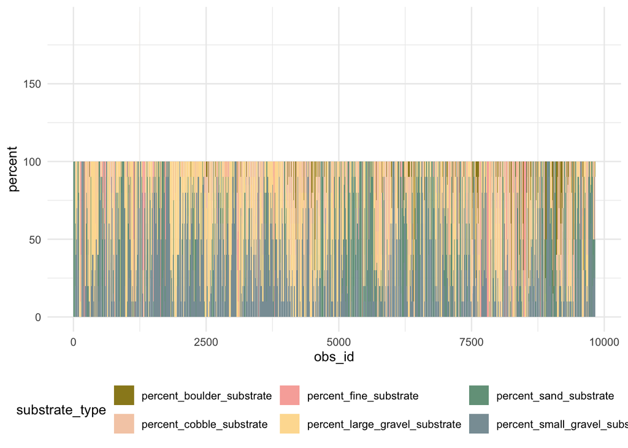

```r
# Make whatever plot is appropriate
# maybe 2+ plots are appropriate
all_fish_data |>
  arrange(river_mile) |>
  mutate(obs_id = 1:nrow(all_fish_data)) |>
  select(obs_id,
         percent_fine_substrate,
         percent_sand_substrate,
         percent_small_gravel_substrate,
         percent_large_gravel_substrate,
         percent_cobble_substrate,
         percent_boulder_substrate) |>
  pivot_longer(cols = percent_fine_substrate:percent_boulder_substrate,
               names_to = "substrate_type", values_to = "percent") |>
  ggplot(aes(x = obs_id, y = percent, fill = substrate_type)) +
  geom_col() +
  scale_fill_manual(values = colors_small) +
  theme_minimal() +
  theme(legend.position = "bottom")
```

**Numeric Summary of substrate over Period of Record**

```r
# Table with summary statistics
summary(all_fish_data$percent_fine_substrate)
```

```
##    Min. 1st Qu.  Median    Mean 3rd Qu.    Max.
##   0.000   0.000   0.000   5.135   0.000 100.000
```

```r
summary(all_fish_data$percent_sand_substrate)
```

```
##    Min. 1st Qu.  Median    Mean 3rd Qu.    Max.
##    0.00    0.00    0.00   16.49   20.00  100.00
```

```r
summary(all_fish_data$percent_small_gravel_substrate)
```

```
##    Min. 1st Qu.  Median    Mean 3rd Qu.    Max.
##    0.00    0.00   20.00   31.51   50.00  100.00
```

```r
summary(all_fish_data$percent_large_gravel_substrate)
```

```
##    Min. 1st Qu.  Median    Mean 3rd Qu.    Max.
##    0.00    0.00   25.00   32.19   50.00  100.00
```

```r
summary(all_fish_data$percent_boulder_substrate)
```

```
##    Min. 1st Qu.  Median    Mean 3rd Qu.    Max.    NA's
##   0.000   0.000   0.000   2.516   0.000 100.000       1
```

```r
summary(all_fish_data$percent_cobble_substrate)
```

```
##    Min. 1st Qu.  Median    Mean 3rd Qu.    Max.    NA's
##    0.00    0.00    0.00   12.18   20.00  100.00       1
```

**NA and Unknown Values**

There are 0 NA values There are 0 NA values There are 0 NA values There are 0 NA values There are 1 NA values There are 1 NA values

### Variable: `inchannel cover`

**Plotting inchannel cover over Period of Record**

Notes: - some cover totals less than 100%

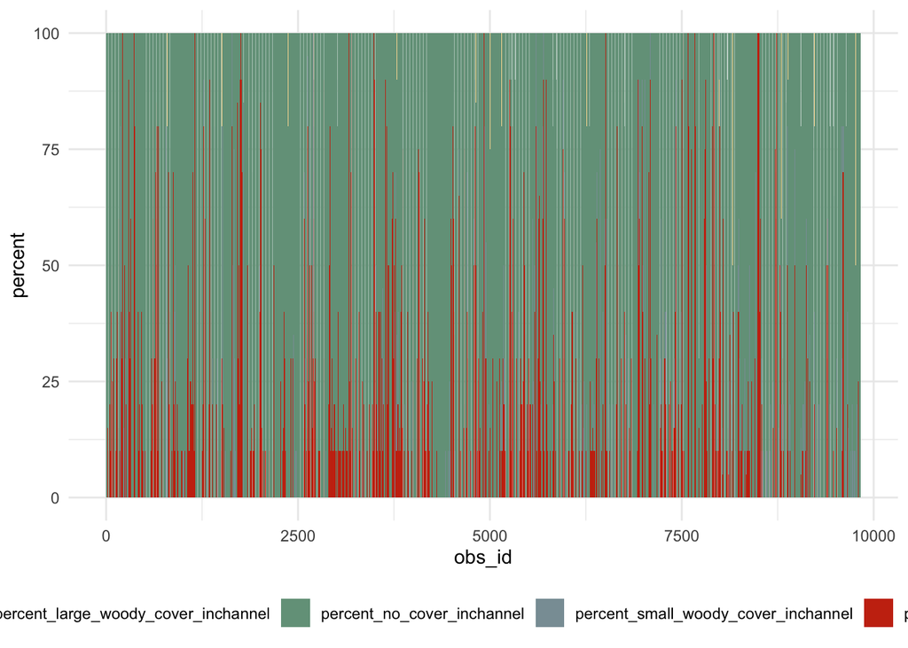

```r
all_fish_data |>
  arrange(river_mile) |>
  mutate(obs_id = 1:nrow(all_fish_data)) |>
  select(obs_id,
         percent_no_cover_inchannel,
         percent_small_woody_cover_inchannel,
         percent_large_woody_cover_inchannel,
         percent_submerged_aquatic_veg_inchannel) |>
  pivot_longer(cols = percent_no_cover_inchannel:percent_submerged_aquatic_veg_inchannel,
               names_to = "inchannel_cover_type", values_to = "percent") |>
  ggplot(aes(x = obs_id, y = percent, fill = inchannel_cover_type)) +
  geom_col() +
  scale_fill_manual(values = colors_small[4:7]) +
  theme_minimal() +
  theme(legend.position = "bottom")
```

**Numeric Summary of inchannel cover over Period of Record**

```r
# Table with summary statistics
summary(all_fish_data$percent_no_cover_inchannel)
```

```
##    Min. 1st Qu.  Median    Mean 3rd Qu.    Max.
##    0.00   70.00   90.00   81.41  100.00  100.00
```

```r
summary(all_fish_data$percent_small_woody_cover_inchannel)
```

```
##    Min. 1st Qu.  Median    Mean 3rd Qu.    Max.
##   0.000   0.000   0.000   3.823   0.000 100.000
```

```r
summary(all_fish_data$percent_large_woody_cover_inchannel)
```

```
##     Min.  1st Qu.   Median     Mean  3rd Qu.     Max.     NA's
##   0.0000   0.0000   0.0000   0.2916   0.0000 100.0000        2
```

```r
summary(all_fish_data$percent_submerged_aquatic_veg_inchannel)
```

```
##    Min. 1st Qu.  Median    Mean 3rd Qu.    Max.
##    0.00    0.00    0.00   14.19   20.00  100.00
```

**NA and Unknown Values**

There are 0 NA values There are 0 NA values There are 2 NA values There are 0 NA values

### Variable: `overhead cover`

**Plotting overhead cover over Period of Record**

Notes: - some cover totals more than 100%

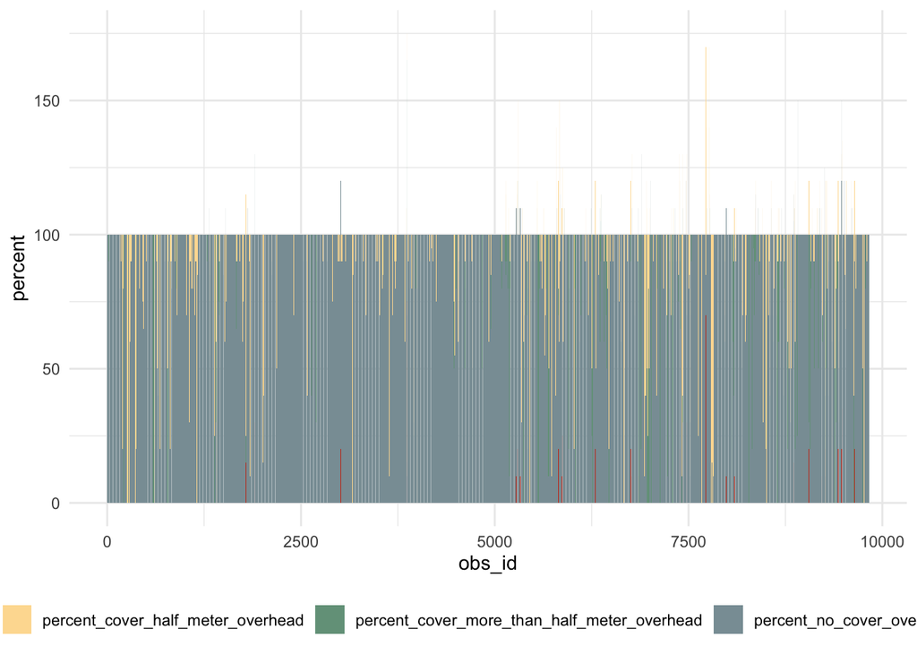

```r
all_fish_data |>
  arrange(river_mile) |>
  mutate(obs_id = 1:nrow(all_fish_data)) |>
  select(obs_id,
         percent_undercut_bank,
         percent_no_cover_overhead,
         percent_cover_half_meter_overhead,
         percent_cover_more_than_half_meter_overhead) |>
  pivot_longer(cols = percent_undercut_bank:percent_cover_more_than_half_meter_overhead,
               names_to = "overhead_cover_type", values_to = "percent") |>
  ggplot(aes(x = obs_id, y = percent, fill = overhead_cover_type)) +
  geom_col() +
  scale_fill_manual(values = colors_small[4:7]) +
  theme_minimal() +
  theme(legend.position = "bottom")
```

**Numeric Summary of overhead cover over Period of Record**

```r
# Table with summary statistics
summary(all_fish_data$percent_undercut_bank)
```

```
##    Min. 1st Qu.  Median    Mean 3rd Qu.    Max.
##  0.0000  0.0000  0.0000  0.2814  0.0000 75.0000
```

```r
summary(all_fish_data$percent_no_cover_overhead)
```

```
##    Min. 1st Qu.  Median    Mean 3rd Qu.    Max.
##     0.0    90.0   100.0    88.8   100.0   100.0
```

```r
summary(all_fish_data$percent_cover_half_meter_overhead)
```

```
##    Min. 1st Qu.  Median    Mean 3rd Qu.    Max.
##   0.000   0.000   0.000   6.788   0.000 100.000
```

```r
summary(all_fish_data$percent_cover_more_than_half_meter_overhead)
```

```
##    Min. 1st Qu.  Median    Mean 3rd Qu.    Max.
##   0.000   0.000   0.000   4.414   0.000 100.000
```

**NA and Unknown Values**

There are 0 NA values There are 0 NA values There are 0 NA values There are 0 NA values

### Variable: `sur_turb`

**Plotting sur_turb over Period of Record**

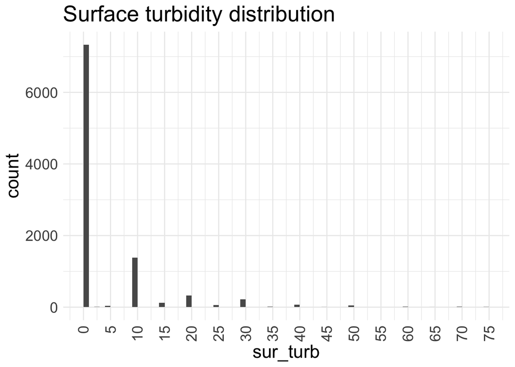

```r
all_fish_data |>
  # filter(fork_length < 250) %>% # filter out 13 points so we can more clearly see distribution
  ggplot(aes(x = sur_turb)) +
  geom_histogram(breaks=seq(0, 75, by=1)) +
  scale_x_continuous(breaks=seq(0, 75, by=5)) +
  theme_minimal() +
  labs(title = "Surface turbidity distribution") +
  theme(text = element_text(size = 18),
        axis.text.x = element_text(angle = 90, vjust = 0.5, hjust=1))
```

**Numeric Summary of sur_turb over Period of Record**

```r
# Table with summary statistics
summary(all_fish_data$sur_turb)
```

```
##    Min. 1st Qu.  Median    Mean 3rd Qu.    Max.    NA's
##   0.000   0.000   0.000   4.677   0.000 100.000     108
```

**NA and Unknown Values**

There are 108 NA values

### Variable: `dist_to_bottom`

**Plotting dist_to_bottom over Period of Record**

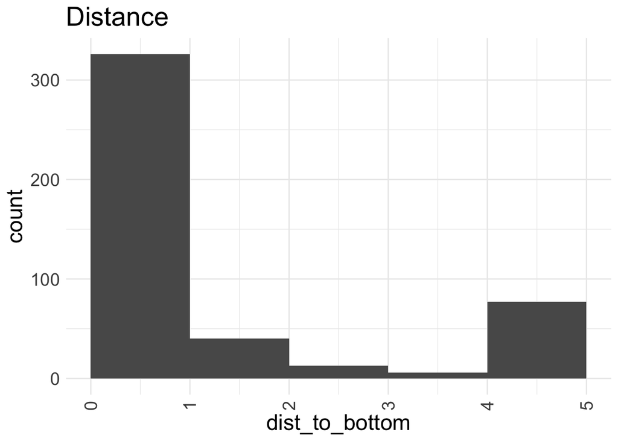

```r
all_fish_data |>
  # filter(fork_length < 250) %>% # filter out 13 points so we can more clearly see distribution
  ggplot(aes(x = dist_to_bottom)) +
  geom_histogram(breaks=seq(0, 5, by=1)) +
  scale_x_continuous(breaks=seq(0, 5, by=1)) +
  theme_minimal() +
  labs(title = "Distance") +
  theme(text = element_text(size = 18),
        axis.text.x = element_text(angle = 90, vjust = 0.5, hjust=1))
```

**Numeric Summary of dist_to_bottom over Period of Record**

```r
# Table with summary statistics
summary(all_fish_data$dist_to_bottom)
```

```
##    Min. 1st Qu.  Median    Mean 3rd Qu.    Max.    NA's
##   0.000   0.080   1.000   6.961   8.000 110.000    9207
```

**NA and Unknown Values**

There are 9207 NA values

### Variable: `fish_data_id`

Looks like there are one more unique fish data id than there is number of rows where joined fish has a count greater than o

```r
nrow(all_fish_data |> filter(count > 0)) == length(unique(all_fish_data$fish_data_id))
```

```
## [1] FALSE
```

**Numeric Summary of fish_data_id over Period of Record**

```r
# Table with summary statistics
summary(all_fish_data$fish_data_id)
```

```
##    Min. 1st Qu.  Median    Mean 3rd Qu.    Max.    NA's
##    11.0   167.8   338.5   340.1   511.2   690.0    9207
```

**NA and Unknown Values**

There are 9207 NA values

### Variable: `micro_hab_data_tbl_id`

There are more observations than unique micro hab ids so there are some micro habitat transects that have more than one row in the table

```r
nrow(all_fish_data) == length(unique(all_fish_data$micro_hab_data_tbl_id))
```

```
## [1] FALSE
```

**Numeric Summary of micro_hab_data_tbl_id over Period of Record**

```r
# Table with summary statistics
summary(all_fish_data$micro_hab_data_tbl_id)
```

```
##    Min. 1st Qu.  Median    Mean 3rd Qu.    Max.
##      18    2412    4802    4890    7348    9981
```

**NA and Unknown Values**

There are 0 NA values

### Variable: `water_temp`

**Plotting water_temp over Period of Record**

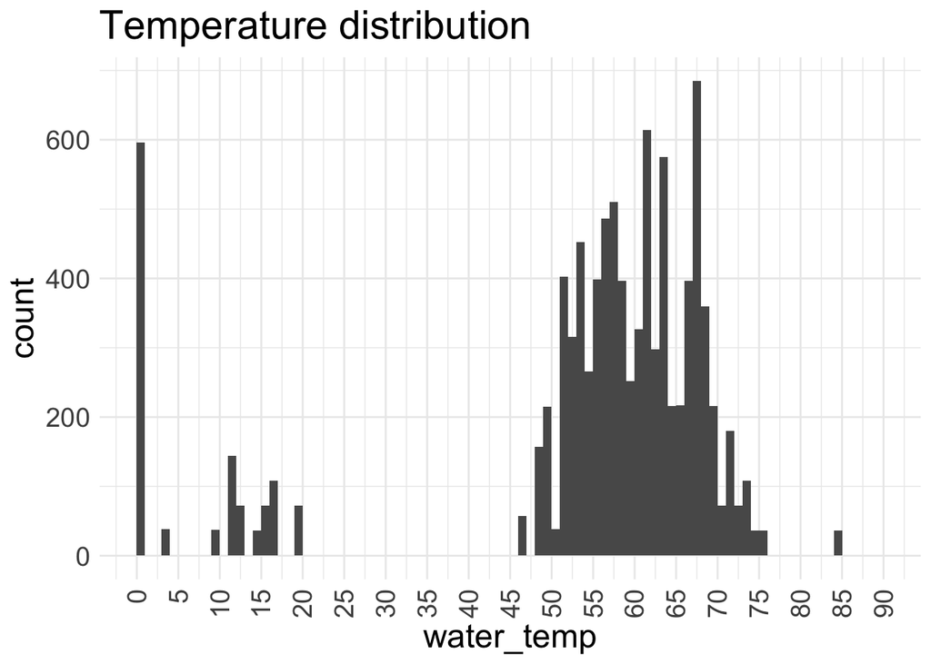

```r
all_fish_data |>
  # filter(fork_length < 250) %>% # filter out 13 points so we can more clearly see distribution
  ggplot(aes(x = water_temp)) +
  geom_histogram(breaks=seq(0, 90, by=1)) +
  scale_x_continuous(breaks=seq(0, 90, by=5)) +
  theme_minimal() +
  labs(title = "Temperature distribution") +
  theme(text = element_text(size = 18),
        axis.text.x = element_text(angle = 90, vjust = 0.5, hjust=1))
```

**Numeric Summary of water_temp over Period of Record**

```r
# Table with summary statistics
summary(all_fish_data$water_temp)
```

```
##    Min. 1st Qu.  Median    Mean 3rd Qu.    Max.    NA's
##    0.00   53.50   59.00   54.39   66.00   85.00     259
```

**NA and Unknown Values**

There are 259 NA values

### Variable: `flow`

**Plotting flow over Period of Record**

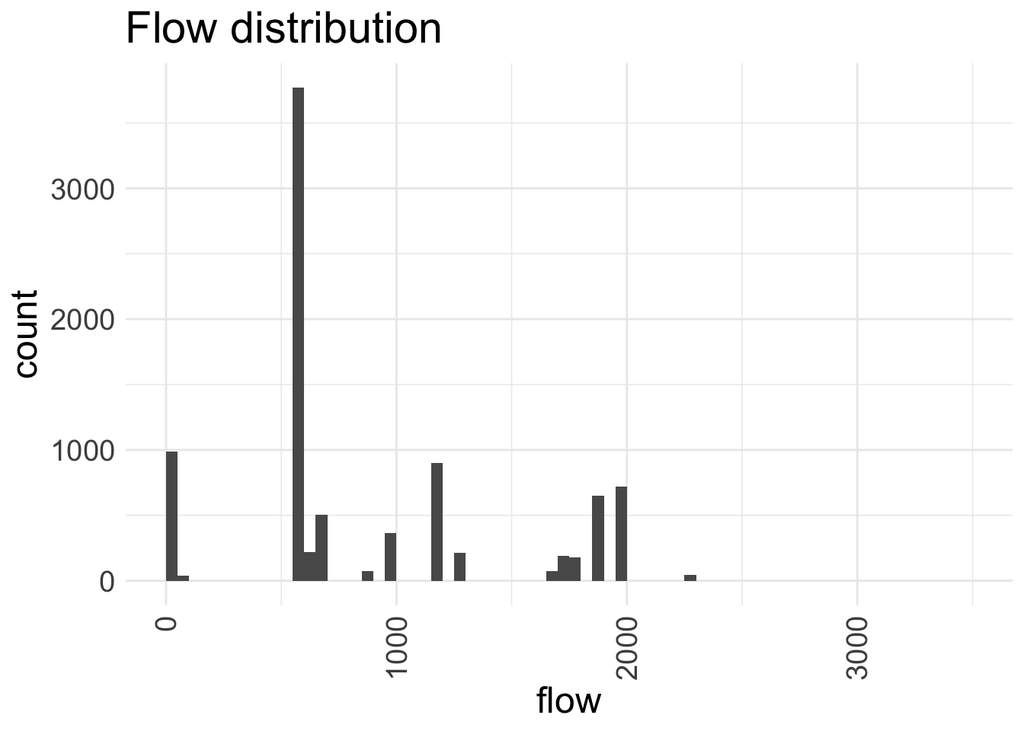

```r
all_fish_data |>
  # filter(fork_length < 250) %>% # filter out 13 points so we can more clearly see distribution
  ggplot(aes(x = flow)) +
  geom_histogram(breaks=seq(0, 3500, by=50)) +
  scale_x_continuous(breaks=seq(0, 3500, by=1000)) +
  theme_minimal() +
  labs(title = "Flow distribution") +
  theme(text = element_text(size = 18),
        axis.text.x = element_text(angle = 90, vjust = 0.5, hjust=1))
```

**Numeric Summary of flow over Period of Record**

```r
# Table with summary statistics
summary(all_fish_data$flow)
```

```
##    Min. 1st Qu.  Median    Mean 3rd Qu.    Max.    NA's
##       0     600     650    1214    1750    6100     144
```

**NA and Unknown Values**

There are 144 NA values

### Variable: `number_of_divers`

**Plotting number_of_divers over Period of Record**

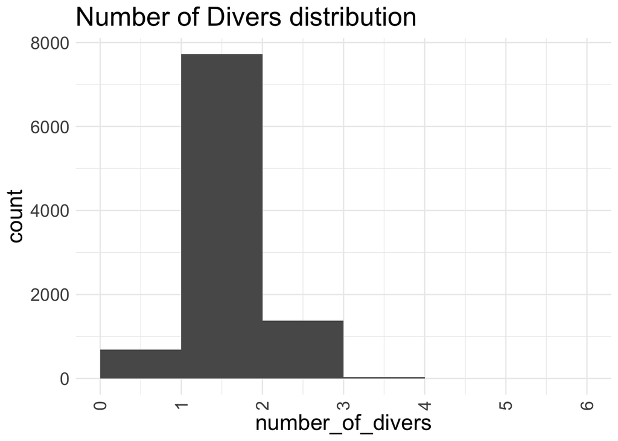

```r
all_fish_data |>
  ggplot(aes(x = number_of_divers)) +
  geom_histogram(breaks=seq(0, 6, by=1)) +
  scale_x_continuous(breaks=seq(0, 6, by=1)) +
  theme_minimal() +
  labs(title = "Number of Divers distribution") +
  theme(text = element_text(size = 18),
        axis.text.x = element_text(angle = 90, vjust = 0.5, hjust=1))
```

**Numeric Summary of number_of_divers over Period of Record**

```r
# Table with summary statistics
summary(all_fish_data$number_of_divers)
```

```
##    Min. 1st Qu.  Median    Mean 3rd Qu.    Max.
##   0.000   2.000   2.000   2.071   2.000   4.000
```

**NA and Unknown Values**

There are 0 NA values

### Variable: `reach_length`

All of the reach lengths are 25 (m?)

**Plotting reach_length over Period of Record**

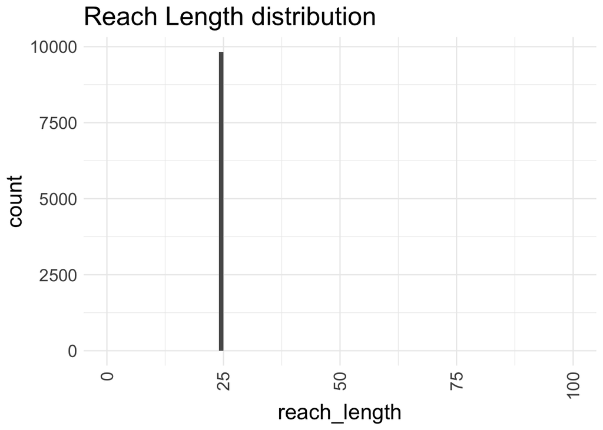

```r
all_fish_data |>
  ggplot(aes(x = reach_length)) +
  geom_histogram(breaks=seq(0, 100, by=1)) +
  scale_x_continuous(breaks=seq(0, 100, by=25)) +
  theme_minimal() +
  labs(title = "Reach Length distribution") +
  theme(text = element_text(size = 18),
        axis.text.x = element_text(angle = 90, vjust = 0.5, hjust=1))
```

**Numeric Summary of reach_length over Period of Record**

```r
# Table with summary statistics
summary(all_fish_data$reach_length)
```

```
##    Min. 1st Qu.  Median    Mean 3rd Qu.    Max.
##      25      25      25      25      25      25
```

**NA and Unknown Values**

There are 0 NA values

### Variable: `reach_width`

All of the reach widths are 4 meters

**Plotting reach_width over Period of Record**

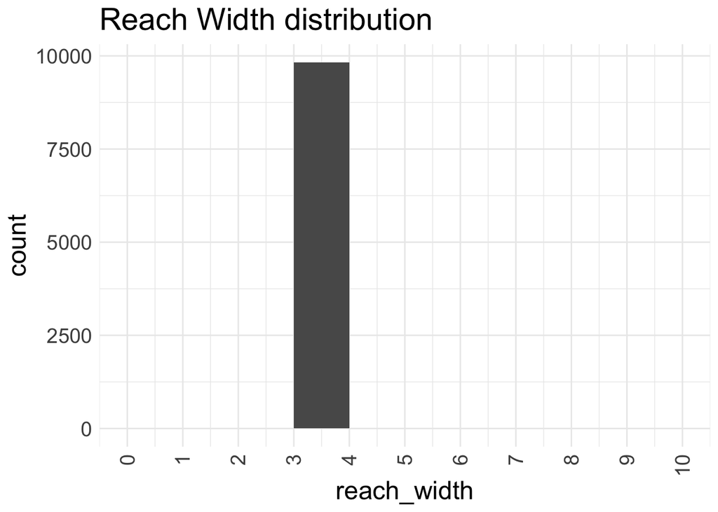

```r
all_fish_data |>
  ggplot(aes(x = reach_width)) +
  geom_histogram(breaks=seq(0, 10, by=1)) +
  scale_x_continuous(breaks=seq(0, 10, by=1)) +
  theme_minimal() +
  labs(title = "Reach Width distribution") +
  theme(text = element_text(size = 18),
        axis.text.x = element_text(angle = 90, vjust = 0.5, hjust=1))
```

**Numeric Summary of reach_width over Period of Record**

```r
# Table with summary statistics
summary(all_fish_data$reach_width)
```

```
##    Min. 1st Qu.  Median    Mean 3rd Qu.    Max.
##       4       4       4       4       4       4
```

**NA and Unknown Values**

There are 0 NA values

### Variable: `chanel_width`

**Plotting chanel_width over Period of Record**

Even through reach width measured is only ever 4 meters sometimes channel width is much larger

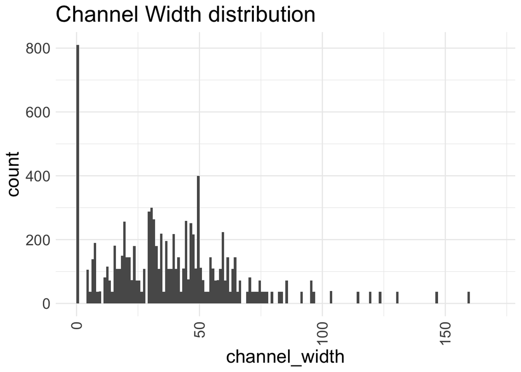

```r
all_fish_data |>
  ggplot(aes(x = channel_width)) +
  geom_histogram(breaks=seq(0, 170, by=1)) +
  scale_x_continuous(breaks=seq(0, 170, by=50)) +
  theme_minimal() +
  labs(title = "Channel Width distribution") +
  theme(text = element_text(size = 18),
        axis.text.x = element_text(angle = 90, vjust = 0.5, hjust=1))
```

**Numeric Summary of chanel_width over Period of Record**

```r
# Table with summary statistics
summary(all_fish_data$channel_width)
```

```
##    Min. 1st Qu.  Median    Mean 3rd Qu.    Max.    NA's
##    0.00   20.00   37.00   39.29   53.00  160.00     219
```

**NA and Unknown Values**

## Explore Categorical variables:

```r
# Filter clean data to show only categorical variables
all_fish_data %>% select_if(is.character) %>% colnames()
```

```
## [1] "species"                 "location"
## [3] "gps_coordinate"          "weather"
## [5] "channel_type"            "channel_geomorphic_unit"
```

### Variable: `location`

```r
table(all_fish_data$location)
```

```
##
##   Across Big Hole Island ( River Right)                    Across from Big Hole
##                                      38                                      36
##          Across From Big Hole Boat Ramp                             Alec Riffle
##                                      36                                      36
##                                Aleck #1                            Aleck Riffle
##                                      72                                     184
##                         Aleck Riffle #2                     Aleck Riffle Sect 3
##                                      36                                      36
##                              Auditorium                       Auditorium Riffle
##                                     159                                     192
##                            Auditorium#3                                 Bedrock
##                                      37                                      76
##                            Bedrock Park                         Bedrock Park #3
##                                      36                                      36
##                         Bedrock Park #4                  Bedrock Park, Unit #50
##                                      37                                      37
##                          Bedrock Riffle                                 big bar
##                                      72                                      36
##                                 Big Bar     Big Bar - Middle Island River Right
##                                     180                                      36
##                              Big Bar #1                                Big Hole
##                                      72                                      72
##                         Big Hole Island                       Big Hole Lower #2
##                                      36                                      72
##                              Cox Riffle                           cox riffle #3
##                                      36                                      36
##                           Cox Riffle #4                           Cox Riffle #5
##                                      36                                      36
##                    Cox Riffle section 3                               East G 95
##                                      36                                      36
##                                     EYE                                  Eye #2
##                                      36                                      41
##                              Eye Riffle                           Eye Riffle #3
##                                     180                                      36
##                            Eye Riffle 4                 Eye Riffle Main Channel
##                                      36                                      36
##                         Eye Riffle Side                 Eye Riffle Side Channel
##                                      37                                      41
##                   Eye Riffle, Unit #208                             Eye side #2
```

[output cut: 128 more lines]

```
##                                      72                                      36
##                                Vance #5                               Vance Ave
##                                      36                                      36
##                            Vance Ave #5                           Vance Ave. #1
##                                      36                                      36
##                            Vance Avenue            Vance Avenue BL - River Left
##                                      36                                      36
##                           Vance East #6                                    Weir
##                                      34                                      36
##                                 weir #2                           Weir Rffle #1
##                                      36                                      36
##                             Weir Riffle                          Weir riffle #2
##                                      72                                      36
##                          weir section 1
##                                      36
```

Fix inconsistencies with spelling, capitalization, and abbreviations.

```r
# Fix any inconsistencies with categorical variables
all_fish_data$location <- tolower(all_fish_data$location)
table(all_fish_data$location)
```

```
##
##   across big hole island ( river right)                    across from big hole
##                                      38                                      36
##          across from big hole boat ramp                             alec riffle
##                                      36                                      36
##                                aleck #1                            aleck riffle
##                                      72                                     184
##                         aleck riffle #2                     aleck riffle sect 3
##                                      36                                      36
##                              auditorium                       auditorium riffle
##                                     159                                     192
##                            auditorium#3                                 bedrock
##                                      37                                      76
##                            bedrock park                         bedrock park #3
##                                      36                                      36
##                         bedrock park #4                  bedrock park, unit #50
##                                      37                                      37
##                          bedrock riffle                                 big bar
##                                      72                                     216
##     big bar - middle island river right                              big bar #1
##                                      36                                      72
##                                big hole                         big hole island
##                                      72                                      36
##                       big hole lower #2                              cox riffle
##                                      72                                      36
##                           cox riffle #3                           cox riffle #4
##                                      36                                      36
##                           cox riffle #5                    cox riffle section 3
##                                      36                                      36
##                               east g 95                                     eye
##                                      36                                      36
##                                  eye #2                              eye riffle
##                                      41                                     180
##                           eye riffle #3                            eye riffle 4
##                                      36                                      36
##                 eye riffle main channel                         eye riffle side
##                                      36                                      37
##                 eye riffle side channel                   eye riffle, unit #208
##                                      41                                      36
##                             eye side #2                        eye side channel
```

[output cut: 110 more lines]

```
##                                     108                                      36
##                                vance #5                               vance ave
##                                      36                                      36
##                            vance ave #5                           vance ave. #1
##                                      36                                      36
##                            vance avenue            vance avenue bl - river left
##                                      36                                      36
##                           vance east #6                                    weir
##                                      34                                      36
##                                 weir #2                           weir rffle #1
##                                      36                                      36
##                             weir riffle                          weir riffle #2
##                                      72                                      36
##                          weir section 1
##                                      36
```

```r
all_fish_data <- all_fish_data |>
  mutate(location = case_when(location %in% c("aleck riffle", "alec riffle") ~ "aleck riffle",
                              location == "hatchery  ditch" ~ "hatchery ditch",
                              location %in% c("hour bars", "hour bar") ~ "hour bars",
         T ~ location))
unique(all_fish_data$location)
```

```
##   [1] "hatchery ditch"
##   [2] "hour bars"
##   [3] "hatchery riffle"
##   [4] "trailer park riffle"
##   [5] "bedrock park"
##   [6] "steep riffle"
##   [7] "robinson side channel"
##   [8] "steep side channel"
##   [9] "robinson riffle"
##  [10] "upper big hole"
##  [11] "lower big hole"
##  [12] "g95"
##  [13] "g95 east"
##  [14] "lower hole"
##  [15] "gridley riffle"
```

[output cut: 145 more lines]

```r
# FIX aleck riffle and alec riffle
# FIX hatchery  ditch and hatchery ditch
```

**NA and Unknown Values**

There are 0 NA values

### Variable: `species`

```r
table(all_fish_data$species)
```

```
##
##             Chinook salmon       Sacramento squawfish
##                        293                         17
##              Speckled dace     Steelhead trout (wild)
##                          6                        294
## Steelhead trout, (clipped)                 Tule perch
##                          5                          5
```

Fix inconsistencies with spelling, capitalization, and abbreviations.

**NA and Unknown Values**

There are 9207 NA values

### Variable: `channel_geomorphic_unit`

```r
table(all_fish_data$channel_geomorphic_unit)
```

```
##
##        Backwater            Glide  Glide Edgewater             Pool
##              236             3867             1594             1926
##           Riffle Riffle Edgewater
##             1016              389
```

**NA and Unknown Values**

There are 799 NA values

### Variable: `gps_coordinate`

```r
table(all_fish_data$gps_coordinate)
```

```
##
##          39 21.224, 121 37.831       39 22.566' N 121 37.949'
##                             36                             36
##          39 27.706  121 36.109          39 27.771  121 36.257
##                             36                             36
##       39 29.09' N 121 37.82' W          39 30.950, 121 33.552
##                             36                             36
##           39.27.957 121.35.991           39.28.981 121.34 736
##                             37                             36
##           39.29.058 121.34.742        39' 27.68', 121' 36.48'
##                             36                             36
##         39°23.167'N 121°37.722        39°25.304'N 121°37.540W
##                             36                             36
##                             70     N 31º 29.68  W 121º 34.765
##                             35                             37
##    N 39  24.340  W 121  37.030      N 39 19.065  W 121 37.381
##                             36                             36
##       N 39 19.212 W 121 37.185        N 39 19.743 W121 37.729
##                             36                             36
##       N 39 19.752 W 121 37.830       N 39 19.842 W 121 37.787
##                             36                             37
##       N 39 19.885 W 121 37.821       N 39 19.905 W 121 37.870
##                             36                             36
##       N 39 20.093 W 121 37.945       N 39 20.170 W 121 37.874
##                             36                             36
##       N 39 20.180 W 121 37.945       N 39 20.729 W 121 37.571
##                             36                             36
##       N 39 20.752 W 121 37.601       N 39 20.755 W 121 37.601
##                             36                             37
##       N 39 20.812 W 121 37.594         N 39 21.27 W 121 37.85
##                             37                             36
##       N 39 21.311 W 121 38.003           N 39 22.4 W 121 38.0
##                             36                             36
##       N 39 22.405 W 121 38.108       N 39 22.498 W 121 37.935
##                             36                             36
##       N 39 23.160 W 121 37.699       N 39 23.176 W 121 37.701
##                             36                             36
##       N 39 23.178 W 121 37.700       N 39 23.185 W 121 37.681
##                             36                             36
##       N 39 24.265 W 121 37.043           N 39 24.9 W 121 37.6
```

[output cut: 146 more lines]

```
##                             36                             36
##           N39 27.87 W121 35.95           N39 27.95 W121 36.03
##                             36                             36
##         N39 29.643 W121 34.792        N39 30.770 W 121 34.145
##                             36                             37
##        N39 30.947 W 121 33.272  N39*  25.824    W121*  37.850
##                             36                             37
##       N39*19.765', W121*37.72'      N39*21.247', W121*37.835'
##                             36                             36
##        N39*23.155  W121*37.722         N39*24.340 W121*37.029
##                             36                             36
##    N39º 20.738', W121º 37.576'     N39º 24.321', W121º 36.982
##                             36                             36
##                           None                      not taken
##                            108                             36
```

**NA and Unknown Values**

There are 2455 NA values

### Variable: `weather`

```r
table(all_fish_data$weather)
```

```
##
## Direct Sunlight        Overcast   Precipitation
##            8628            1086             113
```

**NA and Unknown Values**

There are 0 NA values

### Variable: `channel_type`

```r
table(all_fish_data$channel_type)
```

```
##
##        Mainchannel Mainchannel Branch        Sidechannel
##               4726               2386               2570
```

**NA and Unknown Values**

There are 145 NA values

## Summary of identified issues

- percent cover that is > or < 100%
- did some location name clean up but could be better
- remove sac squawfish
- other?

## Fixing location names and adding coordinates

The location names were reconciled for the 2001 data (see `qc_mini_snorkel_data.Rmd`). Here we will read in the reconciled names and add the 2002 data.

```r
microhabitat_with_fish_detections <- all_fish_data |>
  rename(transect_code = t_code,
         location_table_id = p_dat_id,
         surface_turbidity = sur_turb) |>
  mutate(species = tolower(species),
         species = ifelse(species == "sacramento squawfish","sacramento pikeminnow", species),
         count = ifelse(is.na(count), 0, count),
         channel_geomorphic_unit = tolower(channel_geomorphic_unit),
         channel_geomorphic_unit = case_when(channel_geomorphic_unit == "glide edgewater" ~ "glide margin",
                                             channel_geomorphic_unit == "riffle edgewater" ~ "riffle margin",
                                             T ~ channel_geomorphic_unit)) |>
  select(micro_hab_data_tbl_id, location_table_id, transect_code, fish_data_id, date, count, species, fl_mm, dist_to_bottom, depth, focal_velocity, velocity, surface_turbidity, percent_fine_substrate, percent_sand_substrate, percent_small_gravel_substrate, percent_large_gravel_substrate, percent_cobble_substrate, percent_boulder_substrate, percent_no_cover_inchannel, percent_small_woody_cover_inchannel, percent_large_woody_cover_inchannel, percent_submerged_aquatic_veg_inchannel, percent_undercut_bank, percent_no_cover_overhead, percent_cover_half_meter_overhead, percent_cover_more_than_half_meter_overhead, channel_geomorphic_unit)

survey_locations <- all_fish_data |>
  rename(transect_code = t_code,
         location_table_id = p_dat_id) |>
  mutate(weather = tolower(weather),
         channel_type = tolower(channel_type),
         location_revised = case_when(grepl("big hole", location) ~ "big hole",
                              grepl("auditorium", location) ~ "auditorium riffle",
                              location %in% c("bedrock", "bedrock park", "bedrock park, unit #50") ~ "bedrock riffle",
                              grepl("bedrock", location) ~ "bedrock riffle",
                              grepl("cox", location) ~ "cox riffle", # TODO: is this a new location?
                              grepl("gateway", location) ~ "gateway riffle", # TODO: is this a new location?
                              grepl("goose", location) ~ "goose riffle",
                              grepl("aleck", location) ~ "aleck riffle",
                              grepl("big bar", location) ~ "big bar",
                              grepl("eye", location) ~ "eye riffle",
                              location %in% c("east g 95", "g 95", "g-95 side channel", "g95", "g95 (area)", "g95 east", "g95 rr downstream head", "g95 west side channel") ~ "g95",
                              grepl("g95", location) ~ "g95",
                              grepl("g-95", location) ~ "g95",
                              grepl("g 95", location) ~ "g95",
                              grepl("gridley", location)  ~ "gridley riffle",
                              grepl("grifley", location)  ~ "gridley riffle",
                              grepl("herringer", location) ~ "herringer riffle",
                              grepl("junkyard", location) ~ "junkyard riffle",
                              location == "lower hole" ~ "lower big hole",
                              location == "lower hour side channel" ~ "lower hour",
                              grepl("hour", location) ~ "lower hour",
                              grepl("matthews", location) ~ "matthews riffle",
                              grepl("mathews", location) ~ "matthews riffle",
                              grepl("mcfarland", location) ~ "macfarland riffle",
                              grepl("macfarland", location) ~ "macfarland riffle",
                              grepl("trailer park", location) ~ "trailer park",
                              grepl("trialer", location) ~ "trailer park",
                              grepl("robinson", location) ~ "robinson riffle",
                              grepl("robinsoon", location) ~ "robinson riffle",
                              grepl("shallow", location) ~ "shallow riffle",
                              grepl("steep", location) ~ "steep riffle",
                              grepl("vance", location) ~ "vance avenue",
                              grepl("weir", location) ~ "weir riffle",
                              grepl("hatchery riffle", location) ~ "hatchery riffle",
                              grepl("hatchery ditch", location) ~ "hatchery ditch",
                              T ~ location)) |>
  select(location_table_id, date, location, location_revised, water_temp,
        weather, river_mile, flow, number_of_divers,
        reach_length, reach_width, channel_width,
        channel_type, gps_coordinate) |>
  select(-location) |>
  rename(location = location_revised) |>
  distinct()
```

Okay, let’s compare the names of the 2001/2002 data with the reconciled name list from 2001.

```r
# This is created in the qc_mini_snorkel_data.Rmd
survey_locations_2001 <- read_csv(here::here("data", "archive", "survey_locations.csv"))
# the only two names that exist in the 2002 dataset are and NOT the 2001 are: cox riffle and gateway riffle
setdiff(sort(unique(survey_locations$location)), sort(unique(survey_locations_2001$location)))
```

```
## [1] "cox riffle"     "gateway riffle"
```

```r
# create a location lookup using the 2001 reconciled locations that can be used for 2002 data
lookup <- survey_locations_2001 |>
  select(location, channel_type, longitude, latitude, coordinate_method, channel_location) # river_mile

# joined by location and channel type
location_data_updated <- survey_locations |>
  filter(year(date) == 2002) |>
  left_join(lookup) |>
  select(colnames(survey_locations_2001)) |>
  bind_rows(survey_locations_2001) |>
  arrange(location_table_id) |>
  mutate(latitude = case_when(location == "cox riffle" ~  39.33564114789087, # based off of gps_coordinates
                              location == "gateway riffle" ~ 39.45696577928121,
                              (location == "shallow riffle" & channel_type == "mainchannel branch") ~ 39.32967570030937,
                              (location == "shallow riffle" & channel_type == "mainchannel") ~ 39.33154115157018,
                              T ~ latitude),
         longitude = case_when(location == "cox riffle" ~ -121.63215000396984, # based off of gps_coordinates
                               location == "gateway riffle" ~ -121.62560364814165,
                                (location == "shallow riffle" & channel_type == "mainchannel branch") ~ -121.6285435907359,
                               (location == "shallow riffle" & channel_type == "mainchannel") ~ -121.63033927513442,
                               T ~ longitude),
         coordinate_method = case_when(location %in% c("cox riffle", "gateway riffle") ~ "assigned based on similar location",
                                       (location == "shallow riffle" & channel_type %in%  c("mainchannel branch", "mainchannel")) ~ "assigned based on similar location",
                                       T ~ coordinate_method),
        channel_location = case_when(location == "shallow riffle" ~ "HFC",
                                      location == "trailer park" ~ "LFC", # this removes 1 NA but is consistent with all other trailer parks
                                      T ~ channel_location),
         channel_type = case_when(location == "trailer park" ~ "mainchannel",
                                  T ~ channel_type)) # this removes 1 NA but is consistent with all other trailer parks
# QC
# test_2001 <- location_data_2002 |>
#   filter(year(date) == 2001)
# unique(test_2001 == survey_locations_2001)
```

Location reconciliation that still needs to be done for 2002 data:

- cox riffle and gateway riffles need HFC/LFC designation

Save data:

```r
write_csv(location_data_updated, here::here("data", "survey_locations.csv"))
write_csv(microhabitat_with_fish_detections, here::here("data", "microhabitat_observations.csv"))
```

```r
knitr::knit_exit()
```